# PH525 4x HDDA: Heatmaps

Michael Hunt

April 2, 2016

## Example

```r
library(tissuesGeneExpression)
data(tissuesGeneExpression)
```

```r
library(genefilter)
```

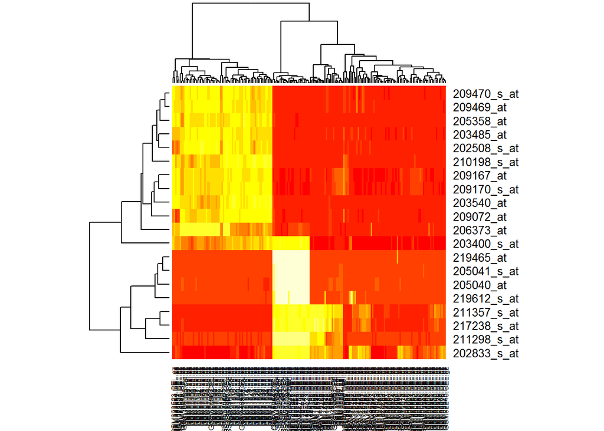

```r
rv<-rowVars(e)
idx<-order(-rv)[1:20] # take 40 genes that vary the most

heatmap(e[idx,]) # on this subset of e
```

Now improve this:

First, the colours - use RColorBrewer

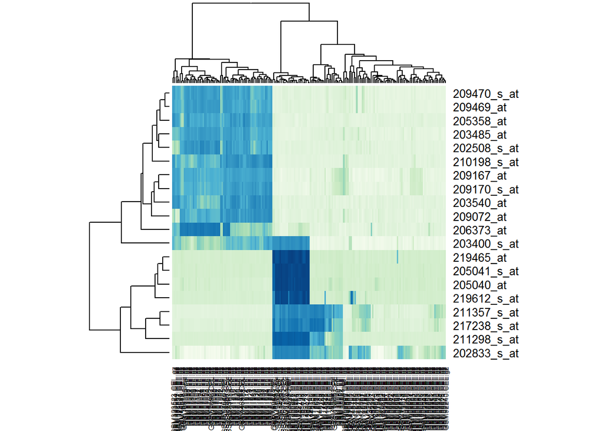

```r
library(RColorBrewer)
hmcol<-colorRampPalette(brewer.pal(9,"GnBu"))(100)
heatmap(e[idx,],col=hmcol)
```

heatmap plot does not reshape itself if we grow the screen. An alternative is heatmap.2 in gplots package.

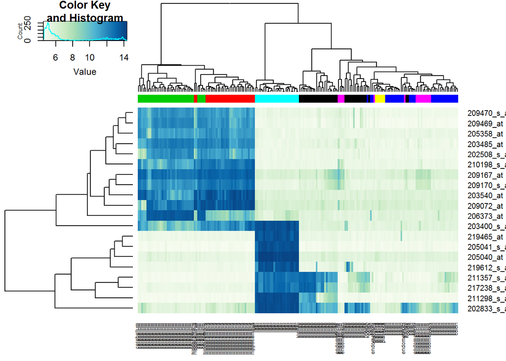

```r
library(gplots)
library(rafalib)

cols<-palette(brewer.pal(7,"Dark2"))[as.fumeric(tissue)] # asigns a colour to each tissue
#cbind(colnames(e),tissue,cols)
heatmap.2(e[idx,],labCol=tissue,
          trace="none", # Rafa never uses this
          ColSideColors=cols,
          col=hmcol)
```

## Exercises

### Heat Maps Exercises #1

Load the data

```r
library(GSE5859Subset)
data(GSE5859Subset)
```

Pick the 25 genes with the highest across sample variance. This function might help

```r
#install.packages("matrixStats")
library(matrixStats)
?rowMads ##we use mads due to a outlier sample
```

```
## starting httpd help server ...
```

```
##  done
```

```r
library(matrixStats)
rv<-rowMads(geneExpression)
idx<-order(rv,decreasing=TRUE)[1:25] # take 25 genees that vary the most
```

Use `heatmap.2` to make a heatmap showing the `sampleInfo$group` with color, the date as labels, the rows labelled with chromosome, and scaling the rows.

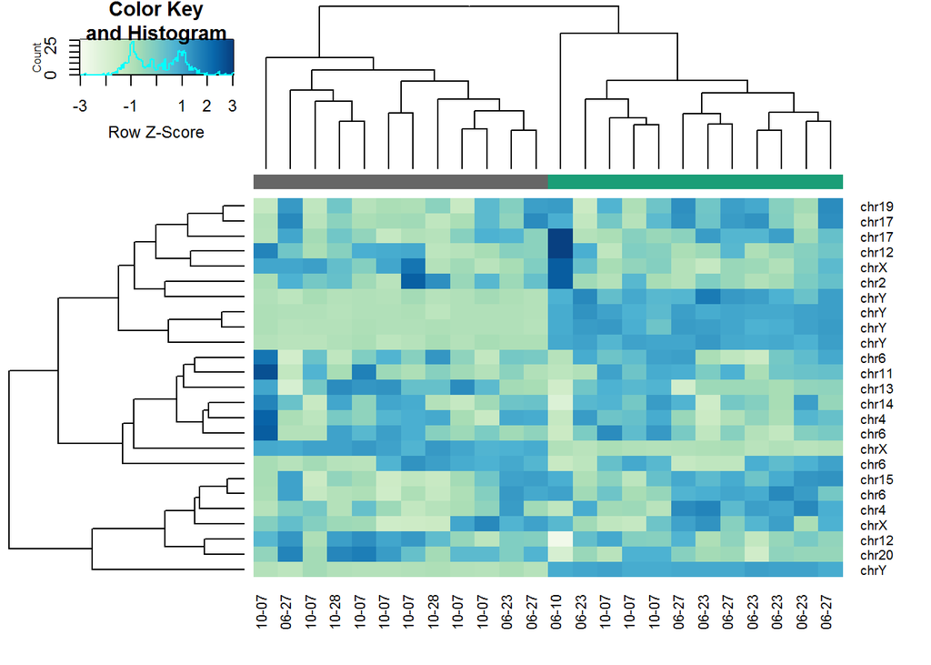

```r
library(gplots)
library(rafalib)
library(RColorBrewer)
hmcol<-colorRampPalette(brewer.pal(9,"GnBu"))(100)
cols<-colorRampPalette(brewer.pal(8,"Dark2"))(2)[as.factor(sampleInfo$group)] # assigns a colour to each group
#cbind(colnames(geneExpression),cols)
heatmap.2(geneExpression[idx,],
          labRow=geneAnnotation$CHR[idx],
          labCol=gsub("2005-","",sampleInfo$date),
          trace="none", # Rafa never uses this
          ColSideColors=cols,
          col=hmcol,
          scale="row")
```

### Model answer to exercise 1

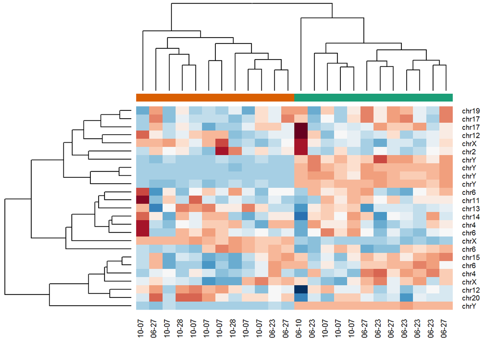

```r
##load libraries
library(rafalib)
library(gplots)
library(matrixStats)
library(RColorBrewer)

##make colors
cols = colorRampPalette(rev(brewer.pal(11,"RdBu")))(25)
gcol=brewer.pal(3,"Dark2")
gcol=gcol[sampleInfo$g+1]

##make lables: remove 2005 since it's common to all
labcol= gsub("2005-","",sampleInfo$date)

##pick highly variable genes:
sds =rowMads(geneExpression)
ind = order(sds,decreasing=TRUE)[1:25]

## make heatmap
heatmap.2(geneExpression[ind,],
          col=cols,
          trace="none",
          scale="row",
          labRow=geneAnnotation$CHR[ind],
          labCol=labcol,
          ColSideColors=gcol,
          key=FALSE)
```

A group of chrY genes are higher in group 0 and appear to drive the clustering. Within those clusters there appears to be clustering by month.

### Heat Maps Exercises #2

Create a large data set of random data that is completely independent of sampleInfo$group like this:

```r
set.seed(17)
m = nrow(geneExpression)
n = ncol(geneExpression)
x = matrix(rnorm(m*n),m,n)
g = factor(sampleInfo$g )
```

Take genes with 50 smallest p-values

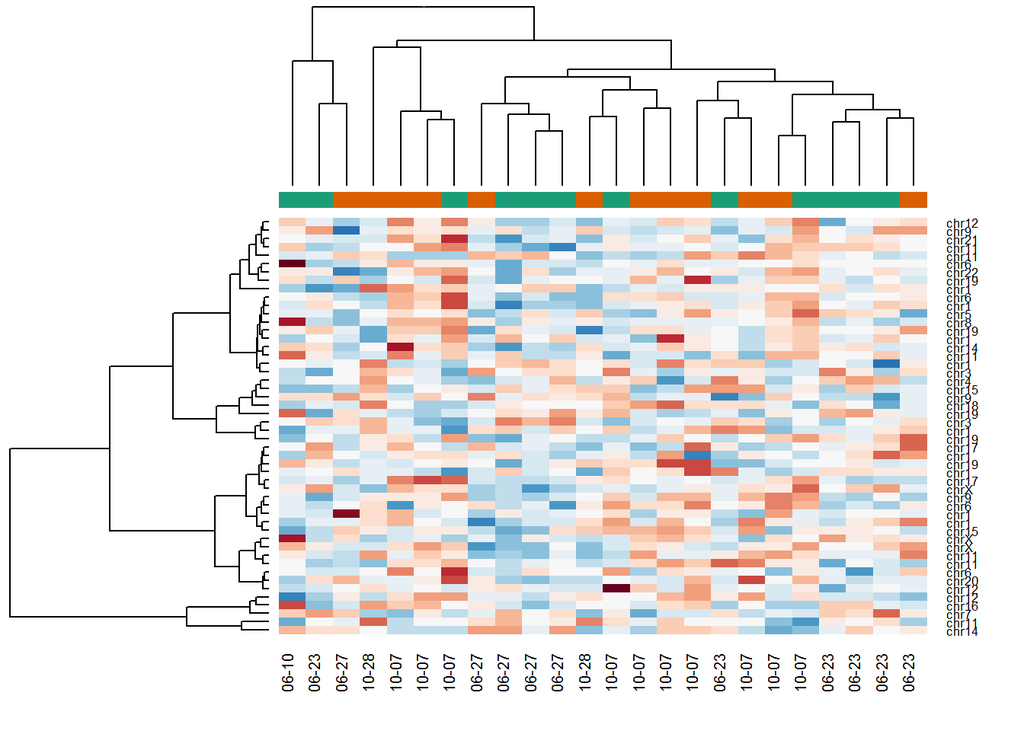

```r
##load libraries
library(rafalib)
library(gplots)
library(matrixStats)
library(RColorBrewer)

##pick genes with smallest p-values:
sds =rowttests(x)
ind = order(sds,decreasing=FALSE)[1:50]
# sds[ind,3]

##make colors
cols = colorRampPalette(rev(brewer.pal(11,"RdBu")))(25)
gcol=brewer.pal(3,"Dark2")
gcol=gcol[sampleInfo$g+1]

## make heatmap
heatmap.2(geneExpression[ind,],
          col=cols,
          trace="none",
          scale="row",
          labRow=geneAnnotation$CHR[ind],
          labCol=labcol,
          ColSideColors=gcol,
          key=FALSE)
```

Taking the 50 genes with largest standard deviations.

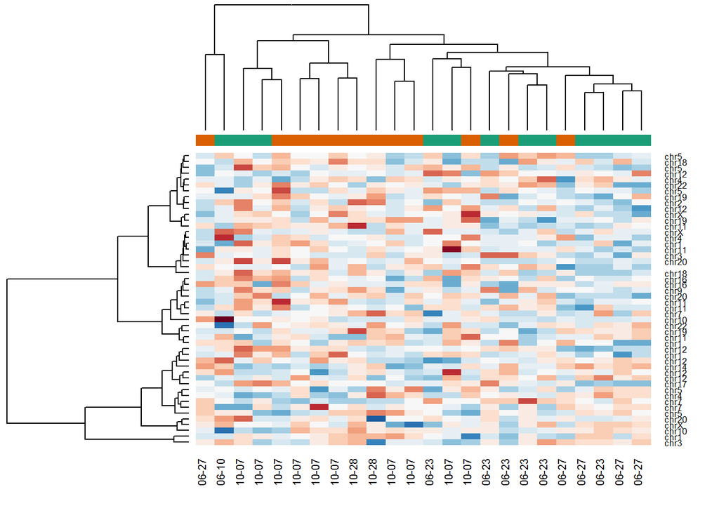

```r
##load libraries
library(rafalib)
library(gplots)
library(matrixStats)
library(RColorBrewer)

##pick genes with smallest p-values:
sds =rowVars(x)
ind = order(sds,decreasing=TRUE)[1:50]
# sds[ind,3]

##make colors
cols = colorRampPalette(rev(brewer.pal(11,"RdBu")))(25)
gcol=brewer.pal(3,"Dark2")
gcol=gcol[sampleInfo$g+1]

## make heatmap
heatmap.2(geneExpression[ind,],
          col=cols,
          trace="none",
          scale="row",
          labRow=geneAnnotation$CHR[ind],
          labCol=labcol,
          ColSideColors=gcol,
          key=FALSE)
```

Model answer:

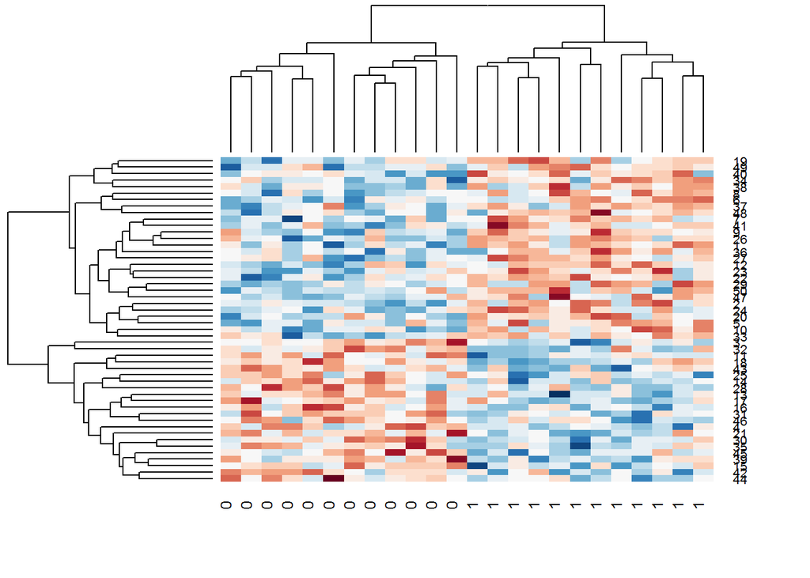

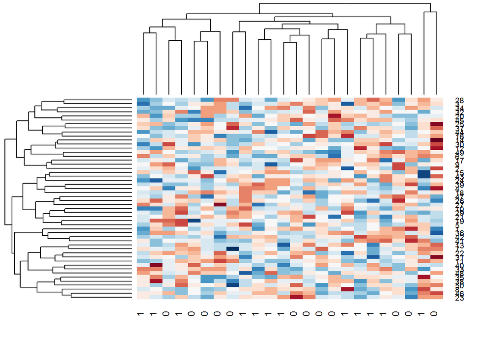

```r
library(gplots)
library(matrixStats)
library(genefilter)
library(RColorBrewer)
cols = colorRampPalette(rev(brewer.pal(11,"RdBu")))(25)

ttest = rowttests(x,g)
sds = rowSds(x)
Indexes = list(t=order(ttest$p.value)[1:50], s=order(-sds)[1:50])
for(ind in Indexes){
 heatmap.2(x[ind,],
          col=cols,
          trace="none",
          scale="row",
          labCol=g,
          key=FALSE)
}
```

There is no relationship between $g$ and $x$ but with 8,793 tests some will appear significant by chance. Selecting genes with the t-test gives us a deceiving result.